# Building Energy Performance Analysis

Adam Dennett

2024-02-22

# Mapping Energy Performance Certificate Data

This guide will walk you through the process of downloading, geo-coding and then mapping data from The UK Government's Department for Levelling Up, Housing and Communities (DLUHC) Domestic Energy Performance Certificate (EPC) Data.

Part 1 is a guide to downloading EPC and Ordnance Survey’s geo-referenced Unique Property Reference Number (UPRN) data from two APIs and linking the two datasets for mapping using R.

Part 2 will explain how to load your newly linked data into QGIS and map it, adding additional contextual data from the OS Zoomstack.

If you are not familiar with R and you want to get straight onto the mapping, download this sample dataset from here and skip straight down to Part 2

# Part 1 - Getting the Data

## Downloading R and RStudio

To run this tutorial you should download and install both R and RStudio onto your machine. Download and install R before you Download and Install R Studio

1. Download R from here: https://www.r-project.org/
2. Download RStudio from here: https://posit.co/products/open-source/rstudio/

If you are unfamiliar with R and RStudio, there are lots of written and video guides out there. Here is an excellent place to start: https://education.rstudio.com/learn/beginner/

Before going any further, make sure you are happy with writing and saving code in .r or .rmd files in a working directory, installing and librarying packages, running basic scripts.

## Creating a file to store your API keys

We will be using API keys that you will need to sign up and have an account for.

1. Visit - https://epc.opendatacommunities.org/ - and sign-up so you can access the data
2. Once signed up, sign in and wait for the email link to be sent to you to connect to the data interface
3. Scroll to the very bottom of the Domestic EPC search front page - here you should find your api key, however, click on the developer API key link below that which should take you to this page - https://epc.opendatacommunities.org/docs/api
4. Click on the Domestic Energy Performance Certificates API link, which should take you to this page - https://epc.opendatacommunities.org/docs/api/domestic
5. Open a new R Script file in RStudio - here you will save the various API key and token information you will need to access the API. Call this file keys.r and save it to your working directory
6. Back on the domestic EPC API page, it will give you information about your API username (probably your email address you signed up with) and your API key. It will also give you two authentication tokens. You need to save these in your new keys.r file.
7. In your new keys.r file, create 4 new variables and assign them the various keys and tokens you have been given, exactly as below (don’t forget the quotation marks!):
   - epc_user <- “your_email@your_domain.com”
   - epc_api_key <- “3a9f3fc………………………………”
   - epc_auth_token <- “YS5kZW……………………….”
   - epc_auth <- “Basic YS5kZW5………………………”
8. Save your keys.r file and close it.

## Get UPRN Data from the OS API

The OS Data Hub has an API which can also be used to download various Open and licence restricted datasets - https://osdatahub.os.uk/ - using the API directly to access the data requires an amount of specialist knowledge (although there is some work in progress documentation here - https://github.com/howaskew/OSapiR), however colleagues at OS have also created an R package called `osdatahub` - https://cran.r-project.org/web/packages/osdatahub/index.html (versions are also available in Python and Javascript - https://github.com/OrdnanceSurvey/os-api-resources)

Below we use the `osdatahub` package to download the Open UPRN dataset from the OS servers.

```r
library(osdatahub)
library(zip)
library(tidyverse)

#get a list of the open datasets
list_os_opendata()
```

```
##                       id                           name
## 1  250kScaleColourRaster 1:250 000 Scale Colour Raster™
## 2           BoundaryLine                 Boundary-Line™
## 3          CodePointOpen               Code-Point® Open
## 4         GBOverviewMaps               GB Overview Maps
## 5              MiniScale                     MiniScale®
## 6           BuiltUpAreas         OS Open Built Up Areas
## 7         OpenGreenspace             OS Open Greenspace
## 8                   LIDS     OS Open Linked Identifiers
## 9              OpenNames                  OS Open Names
## 10            OpenRivers                 OS Open Rivers
## 11             OpenRoads                  OS Open Roads
## 12              OpenTOID                   OS Open TOID
## 13              OpenUPRN                   OS Open UPRN
## 14              OpenUSRN                   OS Open USRN
```

[output cut: 42 more lines]

```r
#we're interested in the OpenUPRN dataset, so get all of the relevant info into an object
uprn = list_os_opendata('OpenUPRN')

#opening up the object, can see that we want the csv, which is the first entry
uprn$fileName[1]
```

```
## [1] "osopenuprn_202402_csv.zip"
```

```r
#now we can download it:
download_os_opendata(uprn,
                     file_name = uprn$fileName[1],
                     output_dir = tempdir())

#get the path to the zipfile you have just downloaded
zip_file <- file.path(tempdir(), uprn$fileName[1])
#find out what the name of the csv is within the zipfile
zip_contents <- zip_list(zip_file)
zip_contents$filename[3]
```

```
## [1] "osopenuprn_202402.csv"
```

```r
csv_file <- zip_contents$filename[3]

# Unzip the file
unzip(zipfile = zip_file, exdir = tempdir())

# Read data from the CSV file
uprn_data <- read_csv(file.path(tempdir(), csv_file)) %>%
  clean_names()
```

## Joining EPC data to UPRN data and cleaning for mapping

- First we will get some Local Authority Boundaries from the Office for National Statistics to ‘trim’ our EPC data with. Sometimes, due to errors in UPRN address matching, some properties are outside of the local authority we are interested in, so we need to drop these from our analysis dataset (we could try to fix, but this will take too long in this example so we’ll just drop them).
- Visit the ONS Geoportal website - https://geoportal.statistics.gov.uk/ - and navigate to a recent set of Local Authority District Boundaries - we’ll go for the ones that are ‘Full extent of the realm and clipped (BFC)’ - at the time of writing, the latest available are from 2023, so we’ll use those.
- If you click on the dataset, you should be presented with a map page - for example, like this: https://geoportal.statistics.gov.uk/datasets/2f0b8074b6ab4af6a1ec30eb66317d12_0/explore?location=54.959083%2C-3.316939%2C6.21
- At the bottom of the page, clicking on the “I want to use this” button reveals - under the ‘View API Resources’ button - a URL to a GeoJson file that you can download. You can copy this and paste it in the code as below
- Be warned - occasionally the URL strings to these files change and the files themselves break. If this happens, try again with another dataset - perhaps from a different year or month. Eventually you should find one that works.

```r
library(geojsonsf)
library(tmap)
#download some local authority boundaries from the ONS Geoportal
LAD_sf <- geojson_sf("https://services1.arcgis.com/ESMARspQHYMw9BZ9/arcgis/rest/services/Local_Authority_Districts_May_2023_UK_BFC_V2/FeatureServer/0/query?outFields=*&where=1%3D1&f=geojson")
```

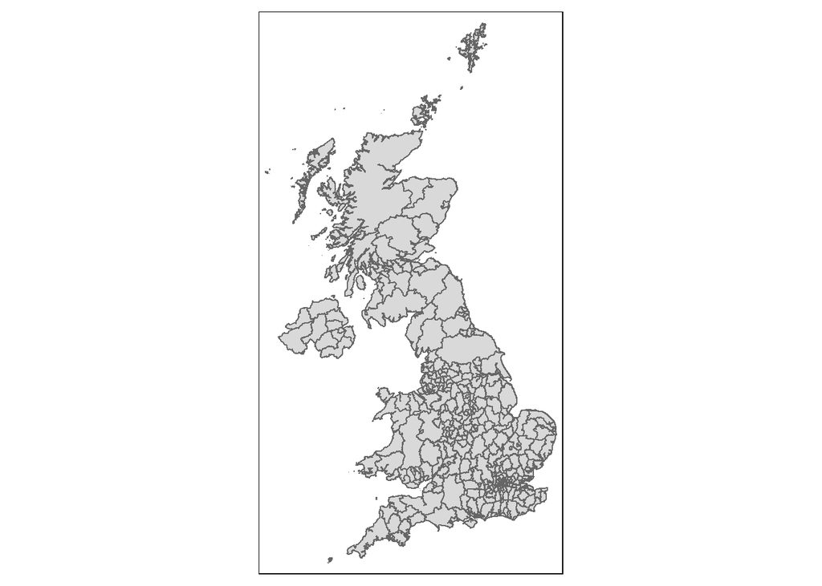

```r
#just plot the boundaries quickly to see if they have downloaded OK
qtm(LAD_sf)
```

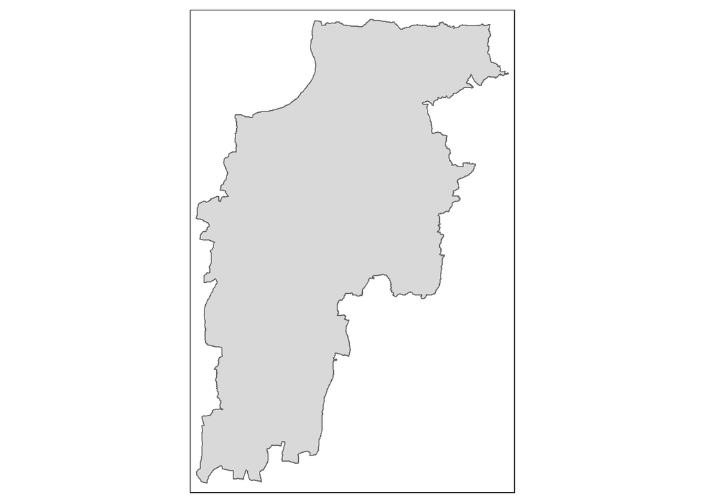

```r
# filter for Mid-Sussex again
Local_sf <- LAD_sf %>% filter(LAD23CD == "E07000228")

qtm(Local_sf)
```

Now we can join some coordinates to our trimmed EPC data to enable us to map it.

```r
#first have a look at the columns within the file. This should tell you that in both files, there are columns called "uprn" - if you haven't cleaned the column headers with janitor, they could be capitalised or something else.
str(epc_data)
```

```
## spc_tbl_ [63,179 × 92] (S3: spec_tbl_df/tbl_df/tbl/data.frame)
##  $ lmk_key                      : chr [1:63179] "0076bfedd101640519682d08edfa40041834ac13d79a36a33b75ffcaf7c32b3a" "03c1671502f4d2b04c866fd87271a84be6f502cb14221dd4edbfb556d2ccd2e1" "0478839c6601a28bb1390792fc38b97aeb533fdd862faf0424a42d42c8b67508" "0d69becf0bf0f4ea8a7affd722ddfa257a03315036c673e…
##  $ address1                     : chr [1:63179] "30 Inholmes Park Road" "15 Lucastes Road" "107 Wilmington Way" "100 Priory Way" ...
##  $ address2                     : chr [1:63179] NA NA NA NA ...
##  $ address3                     : chr [1:63179] NA NA NA NA ...
##  $ postcode                     : chr [1:63179] "RH15 0JE" "RH16 1JN" "RH16 3JD" "RH16 3NP" ...
##  $ building_reference_number    : chr [1:63179] "10005477056" "10005448235" "10005436595" "10005435546" ...
##  $ current_energy_rating        : chr [1:63179] "B" "C" "C" "D" ...
##  $ potential_energy_rating      : chr [1:63179] "B" "C" "C" "B" ...
##  $ current_energy_efficiency    : num [1:63179] 88 70 72 65 68 74 69 74 42 68 ...
##  $ potential_energy_efficiency  : num [1:63179] 91 80 76 84 85 76 83 77 70 84 ...
##  $ property_type                : chr [1:63179] "House" "House" "Flat" "House" ...
##  $ built_form                   : chr [1:63179] "Semi-Detached" "Detached" "End-Terrace" "Semi-Detached" ...
##  $ inspection_date              : Date[1:63179], format: "2024-01-25" "2024-01-31" ...
##  $ local_authority              : chr [1:63179] "E07000228" "E07000228" "E07000228" "E07000228" ...
##  $ constituency                 : chr [1:63179] "E14000817" "E14000817" "E14000817" "E14000817" ...
##  $ county                       : chr [1:63179] "West Sussex" "West Sussex" "West Sussex" "West Sussex" ...
##  $ lodgement_date               : Date[1:63179], format: "2024-01-31" "2024-01-31" ...
##  $ transaction_type             : chr [1:63179] "not sale or rental" "marketed sale" "rental" "marketed sale" ...
##  $ environment_impact_current   : num [1:63179] 84 63 73 61 65 77 66 75 34 65 ...
##  $ environment_impact_potential : num [1:63179] 87 75 79 82 84 80 80 79 61 81 ...
##  $ energy_consumption_current   : num [1:63179] 63 172 212 248 234 178 200 174 360 218 ...
##  $ energy_consumption_potential : num [1:63179] 45 107 164 99 84 160 100 149 173 97 ...
##  $ co2_emissions_current        : num [1:63179] 1.5 5.6 1.7 3.2 2.5 1.6 3.2 1.8 10.3 2.9 ...
##  $ co2_emiss_curr_per_floor_area: num [1:63179] 12 31 37 44 41 31 35 31 65 38 ...
##  $ co2_emissions_potential      : num [1:63179] 1.1 3.5 1.3 1.3 0.9 1.4 1.6 1.5 5.1 1.4 ...
##  $ lighting_cost_current        : num [1:63179] 177 178 108 100 86 113 119 99 367 104 ...
##  $ lighting_cost_potential      : num [1:63179] 177 178 68 100 86 81 119 99 191 104 ...
##  $ heating_cost_current         : num [1:63179] 956 1770 530 1024 703 ...
##  $ heating_cost_potential       : num [1:63179] 895 1498 415 773 640 ...
##  $ hot_water_cost_current       : num [1:63179] 247 264 143 163 259 143 194 158 494 184 ...
##  $ hot_water_cost_potential     : num [1:63179] 159 160 143 107 122 143 131 158 191 123 ...
##  $ total_floor_area             : num [1:63179] 131 179 46 73 61 51 91 59 159 76 ...
##  $ energy_tariff                : chr [1:63179] "Single" "Single" "Unknown" "Single" ...
##  $ mains_gas_flag               : chr [1:63179] "Y" "Y" "Y" "Y" ...
##  $ floor_level                  : chr [1:63179] NA NA "02" NA ...
##  $ flat_top_storey              : chr [1:63179] NA NA "Y" NA ...
##  $ flat_storey_count            : num [1:63179] NA NA NA NA NA NA NA NA NA NA ...
##  $ main_heating_controls        : num [1:63179] NA NA NA NA NA NA NA NA NA NA ...
##  $ multi_glaze_proportion       : num [1:63179] 100 100 100 100 100 100 100 100 100 100 ...
```

[output cut: 134 more lines]

```
##   ..   `solar-water-heating-flag` = col_character(),
##   ..   `mechanical-ventilation` = col_character(),
##   ..   address = col_character(),
##   ..   `local-authority-label` = col_character(),
##   ..   `constituency-label` = col_character(),
##   ..   posttown = col_character(),
##   ..   `construction-age-band` = col_character(),
##   ..   `lodgement-datetime` = col_datetime(format = ""),
##   ..   tenure = col_character(),
##   ..   `fixed-lighting-outlets-count` = col_double(),
##   ..   `low-energy-fixed-light-count` = col_double(),
##   ..   uprn = col_double(),
##   ..   `uprn-source` = col_character()
##   .. )
##  - attr(*, "problems")=<externalptr>
```

```r
str(uprn_data)
```

```
## spc_tbl_ [40,693,173 × 5] (S3: spec_tbl_df/tbl_df/tbl/data.frame)
##  $ uprn        : num [1:40693173] 1 26 27 30 31 32 33 34 38 41 ...
##  $ x_coordinate: num [1:40693173] 358261 352967 352967 354800 354796 ...
##  $ y_coordinate: num [1:40693173] 172797 181077 181077 180469 180460 ...
##  $ latitude    : num [1:40693173] 51.5 51.5 51.5 51.5 51.5 ...
##  $ longitude   : num [1:40693173] -2.6 -2.68 -2.68 -2.65 -2.65 ...
##  - attr(*, "spec")=
##   .. cols(
##   ..   UPRN = col_double(),
##   ..   X_COORDINATE = col_double(),
##   ..   Y_COORDINATE = col_double(),
##   ..   LATITUDE = col_double(),
##   ..   LONGITUDE = col_double()
##   .. )
##  - attr(*, "problems")=<externalptr>
```

```r
#Join the epc_data and uprn_data files together using a left_join() function. Join on the common UPRN identifier. Then, immediately filter out all of the rows without uprns (and therefore coordinates) by piping the newly joined data into a filter function
epc_coords <- left_join(epc_data, uprn_data, by = join_by(uprn == uprn)) %>%
  filter(!is.na(uprn))

#now write your new clean, joined data file out to a CSV
write_csv(epc_coords, here("epc_coords.csv"))
```

## Mapping Your New Data

- It is possible to map your data directly in R, however, in this exercise we are going to eventually map it in QGIS.
- We can have a quick glimpse at the data though by converting our new joined dataset into a simple features (sf) object and viewing it.

```r
library(sf)
#convert the csv with coordinates in it to an sf object
epc_sf <- st_as_sf(epc_coords, coords=c("x_coordinate", "y_coordinate"), crs=27700)

#set the CRS to british national grid
st_crs(Local_sf)
```

```
## Coordinate Reference System:
##   User input: 4326
##   wkt:
## GEOGCS["WGS 84",
##       DATUM["WGS_1984",
##         SPHEROID["WGS 84",6378137,298.257223563,
##           AUTHORITY["EPSG","7030"]],
##         AUTHORITY["EPSG","6326"]],
##       PRIMEM["Greenwich",0,
##         AUTHORITY["EPSG","8901"]],
##       UNIT["degree",0.0174532925199433,
##         AUTHORITY["EPSG","9122"]],
##       AXIS["Latitude",NORTH],
##       AXIS["Longitude",EAST],
##     AUTHORITY["EPSG","4326"]]
```

```r
Local_sf <- st_transform(Local_sf, 27700)

#clip it as some weird places are in the dataset - data errors.
epc_sf_clip <- epc_sf[Local_sf,]
```

```r
#try and map it with tmap
library(tmap)

# set to plot otherwise if you set to view, it will almost certainly crash.
tmap_mode("plot")
```

```
## tmap mode set to plotting
```

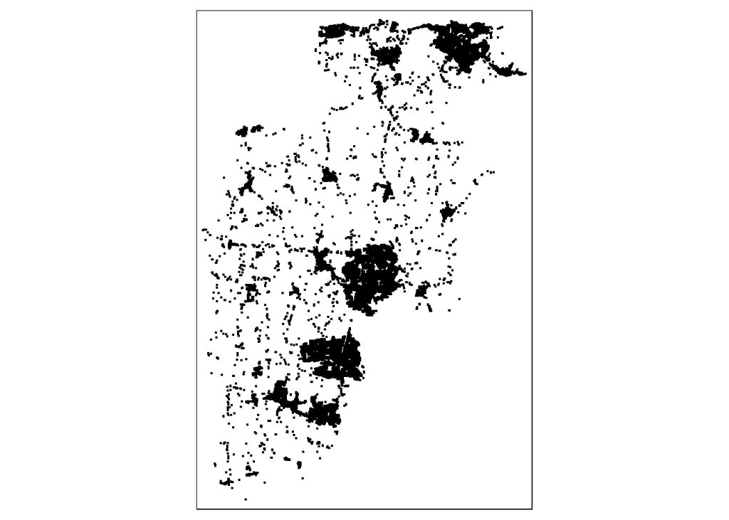

```r
qtm(epc_sf_clip)
```

# Part 2 - Making Some Maps